# [DRAFT] Analysis of Software and Data Carpentry’s Pre- and Post-Workshop Surveys

In the figure below we show another representation of the pre- and post-comparison of respondents skills and perspectives.

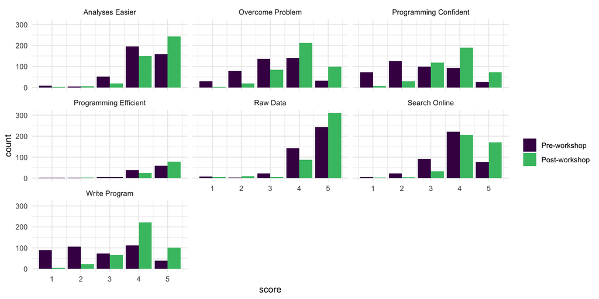

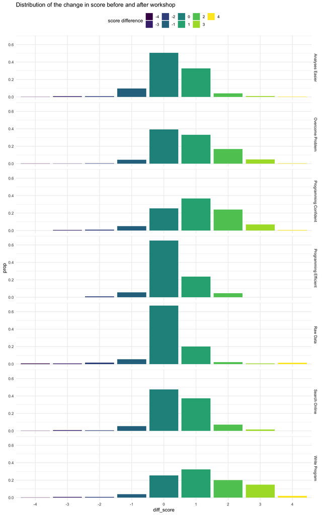

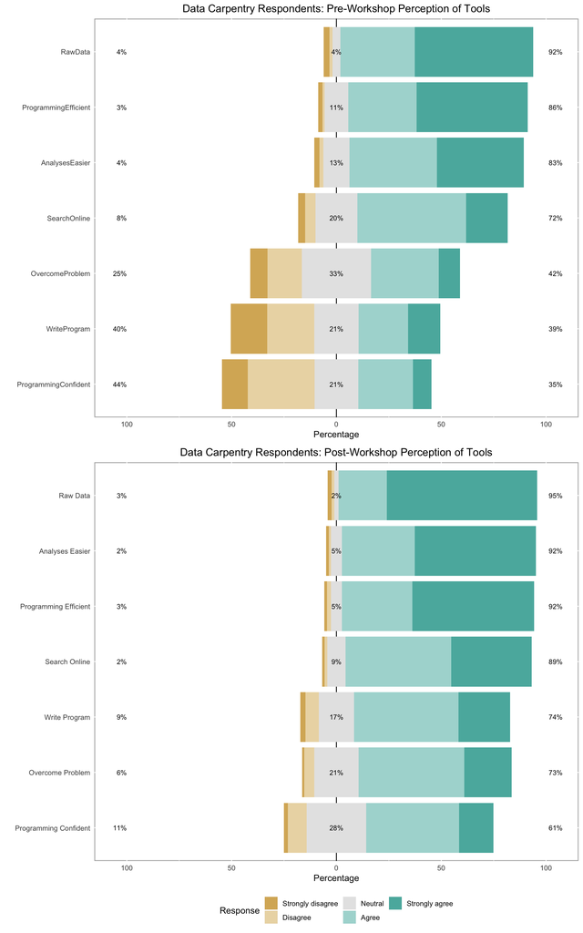

Software Carpentry Respondets were asked to tell us about their experience with these topics before the workshop:

- R
- Unix Shell
- SQL
- Python
- Version Control with Git

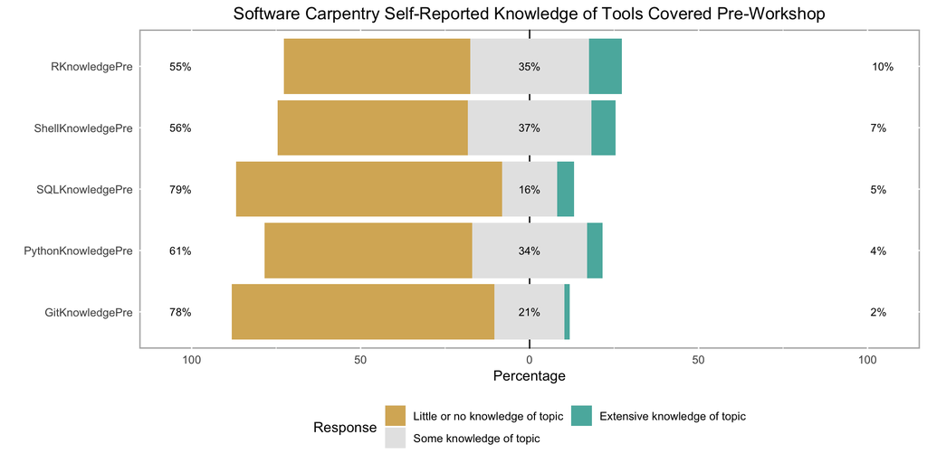

The following is a comparison of Software Carpentry Respondents’ knowledge about the tools before compared to after the workshop.

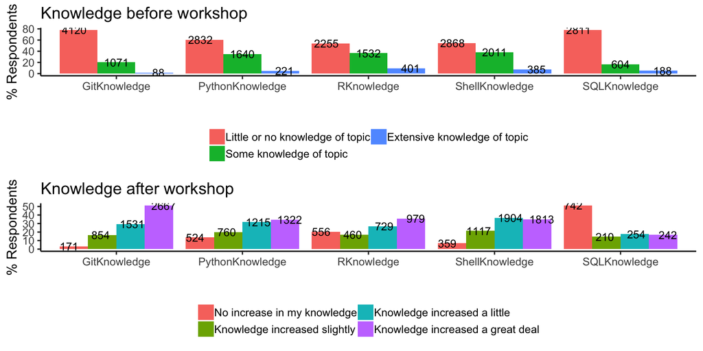